# Homework 4

Claire Hemingway

September 29, 2016

Problem 1

Every Saturday, at the same time, a primatologist goes and sits in the forest in the morning and listens for titi monkey calls, counting the number of calls they hear in a 2 hour window from 5am to 7am. Based on previous knowledge, she believes that the mean number calls she will hear in that time is exactly 15. Let $X$ represent the appropriate Poisson random variable of the number of calls heard in each monitoring session.

1. what is the probability that she will hear more than 8 calls during any given session?

```r
proba<-(1-ppois(7, lambda =15))
proba
```

```
## [1] 0.9819978
```

2. what is the probability that she will hear no calls in a session?

```r
probb<-dpois(0, lambda=15)
probb
```

```
## [1] 3.059023e-07
```

3. what is the probability that she will hear exactly 3 calls in a session?

```r
probc<-dpois(3, lambda=15)
probc
```

```
## [1] 0.0001720701
```

4. plot the relevant Poisson mass function over the values in range 0 (less than or equal to) $X$ (less than or equal to 30).

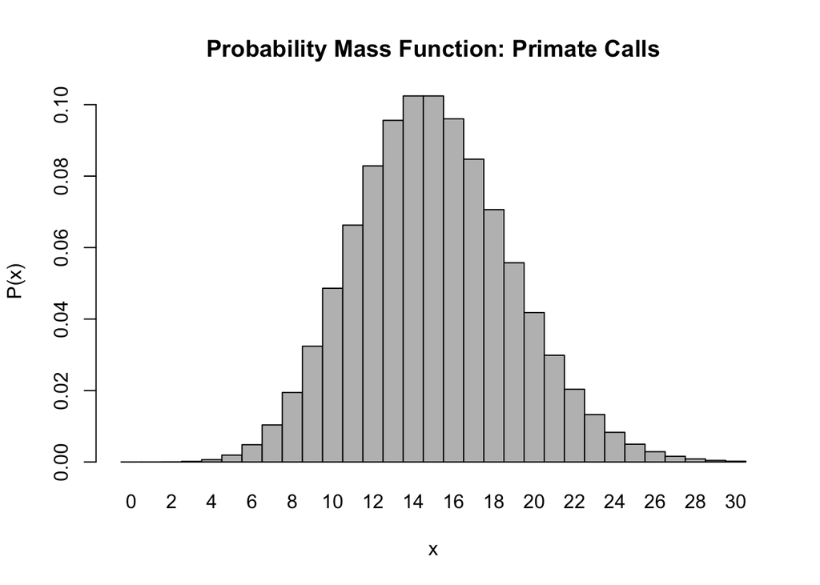

```r
x<- 0:30
dataset<-dpois(x, lambda = 15)
barplot(dataset, names.arg=x, space=0, xlab="x", ylab="P(x)", main="Probability Mass Function: Primate Calls")
```

5. simulate 104 result from this distributio (i.e., 2 years of Saturday monitoring session)

```r
saturdayses<-rpois(104, lambda=15)
saturdayses
```

```
##   [1] 21 11 20 17 23 12 10 20 14 15 20 19 17 10 13 17 14 10 18 20 17 10 12
##  [24] 16 20 16 16 15 16 11 15  7 11  7 20 11 16 19 13 18 12 16 21 16  8 16
##  [47] 10 12 12 15 13 16  8 22 15 12 19 22 21 14 15 19 16 20 10 17 16 16 12
##  [70] 17 16 22 18 14 14 14 13 11 15 13 16 17 15 10 14 14 18 14 16 10 15 19
##  [93] 20 14 20 16 14 18 19 18 15 14 14 19
```

6. plot the simulated result using hist() and use xlim() to set the horizonal limits to be from 0 to 30. How does your histogram compare to the shape of the probability mass function you plotted above?

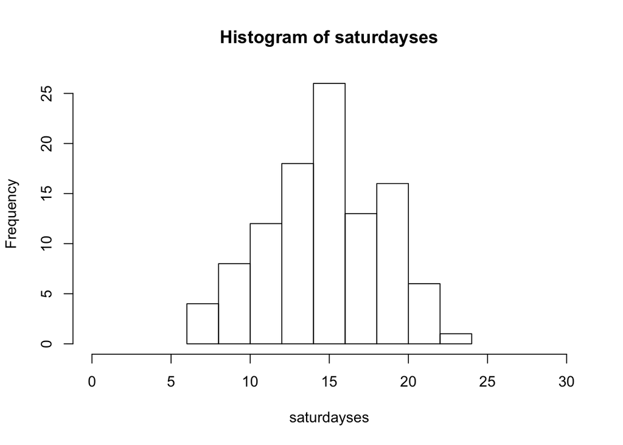

```r
hist(saturdayses, xlim=c(0,30))
```

as we increase the number of samples we would expect that it would conform to the shape of our Poisson mass function.

Here is an example of the same thing with 1000 observations now:

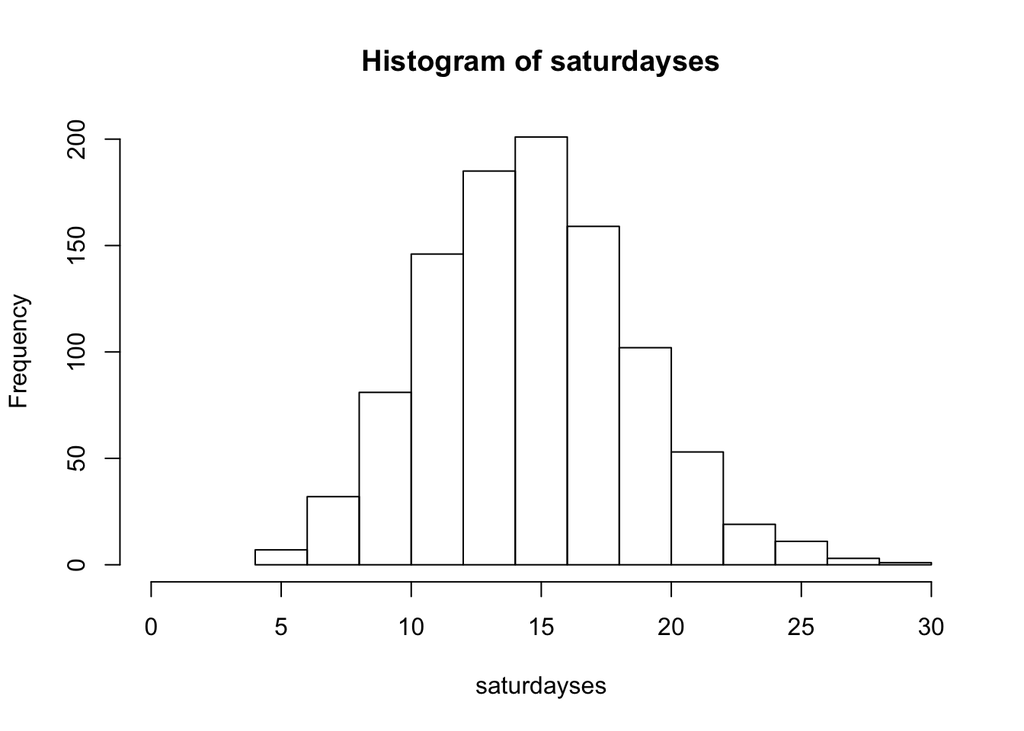

```r
saturdayses<-rpois(1000, lambda=15)
hist(saturdayses, xlim=c(0,30))
```